# Homework 3

Jordan Atkins

2025-02-11

# Problem 1

## Theory A:

### Claim: Gas stations charge more if they lack direct competition in sight.

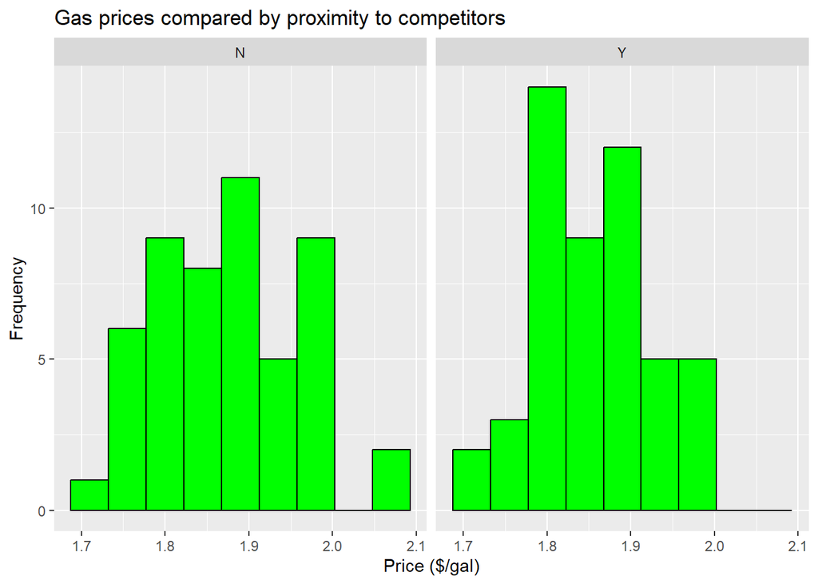

```
## [1] 1.89
```

```
## [1] 1.85
```

I used the histograms of the gas prices of stations near competition and those without as well as the medians of both of these graphs. The histogram for station with competition (y) is approximately normal and the stations without (n) are bi modal with more stations having prices near or above $2. When comparing the medians of these graphs the median for stations with competition (y) was 1.85 and for those without was 1.89. Based on the evidence above I conclude that there is not significant evidence to support gas stations charging more when there are no competitors. Thes values are not significant enough to quantify a conclusion

## Theory B:

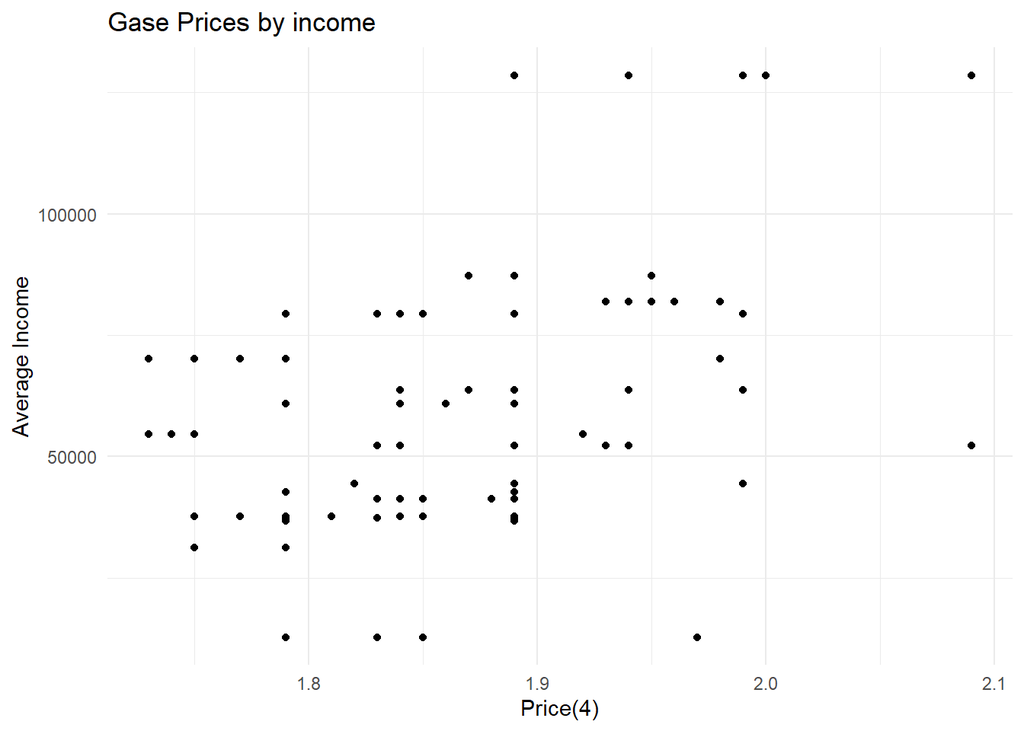

```
## [1] 0.3961546
```

```
##
## Call:
## lm(formula = Price ~ Income, data = gas)
##
## Residuals:
##       Min        1Q    Median        3Q       Max
## -0.150945 -0.050492 -0.009412  0.046076  0.231262
##
## Coefficients:
##                 Estimate   Std. Error t value             Pr(>|t|)
## (Intercept) 1.7934424994 0.0181144760  99.006 < 0.0000000000000002 ***
## Income      0.0000012483 0.0000002908   4.293            0.0000412 ***
## ---
## Signif. codes:  0 '***' 0.001 '**' 0.01 '*' 0.05 '.' 0.1 ' ' 1
##
## Residual standard error: 0.07522 on 99 degrees of freedom
## Multiple R-squared:  0.1569, Adjusted R-squared:  0.1484
## F-statistic: 18.43 on 1 and 99 DF,  p-value: 0.00004117
```

```
##                       2.5 %         97.5 %
## (Intercept) 1.7574994490237 1.829385549809
## Income      0.0000006713493 0.000001825333
```

## Theory C

### Gas stations at stoplights charge more

```
## # A tibble: 2 × 4
##   Stoplight median_price sd_price     n
##   <chr>            <dbl>    <dbl> <int>
## 1 N                 1.84   0.0914    38
## 2 Y                 1.87   0.0757    63
```

```
##
##  Welch Two Sample t-test
##
## data:  Price by Stoplight
## t = 0.18717, df = 67.053, p-value = 0.8521
## alternative hypothesis: true difference in means between group N and group Y is not equal to 0
## 95 percent confidence interval:
##  -0.03189060  0.03849043
## sample estimates:
## mean in group N mean in group Y
##        1.866316        1.863016
```

```
## [1] -0.03189060  0.03849043
## attr(,"conf.level")
## [1] 0.95
```

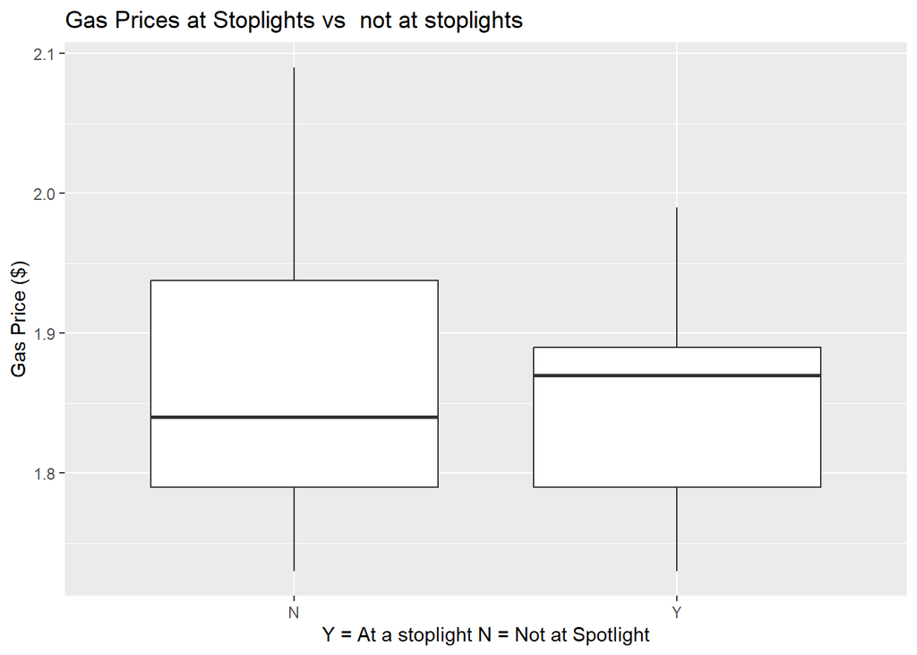

The evidence does not support the claim that gas stations at stoplights charge more. The observed difference in gas prices is almost zero (-0.3 cents), and the p-value is very high (0.8521), meaning the difference is likely due to chance. The 95% confidence interval includes zero, further confirming that there is no meaningful difference.

## Theory D

```
## # A tibble: 2 × 4
##   Highway mean_price sd_price     n
##   <fct>        <dbl>    <dbl> <int>
## 1 N             1.85   0.0807    79
## 2 Y             1.9    0.0759    22
```

```
##
##  Welch Two Sample t-test
##
## data:  Price by Highway
## t = -2.4628, df = 35.344, p-value = 0.0188
## alternative hypothesis: true difference in means between group N and group Y is not equal to 0
## 95 percent confidence interval:
##  -0.083350777 -0.008041628
## sample estimates:
## mean in group N mean in group Y
##        1.854304        1.900000
```

```
## [1] -0.083350777 -0.008041628
## attr(,"conf.level")
## [1] 0.95
```

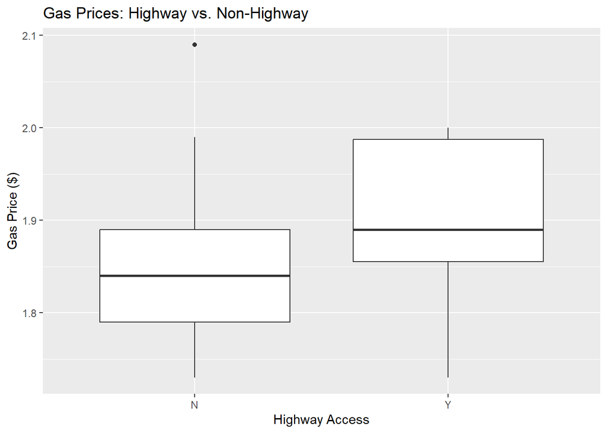

The boxplot for Highway vs non-highway stations hows stations with highway access to have slightly higher median gas price and high upper bounds and lower pounds he evidence suggests that gas stations on the highway charge significantly more (between 0.8 and 8.3 cents per gallon more, with 95% confidence). Since the p-value is below 0.05, we reject the null hypothesis and conclude that there is a significant price difference favoring higher prices on the highway.

## Theory E

### Shell charges more than all other non-Shell brand

```
## # A tibble: 2 × 4
##   Shell mean_price sd_price     n
##   <fct>      <dbl>    <dbl> <int>
## 1 Other       1.86   0.0765    72
## 2 Shell       1.88   0.0912    29
```

```
##
##  Welch Two Sample t-test
##
## data:  Price by Shell
## t = -1.4278, df = 44.703, p-value = 0.1603
## alternative hypothesis: true difference in means between group Other and group Shell is not equal to 0
## 95 percent confidence interval:
##  -0.06606937  0.01126094
## sample estimates:
## mean in group Other mean in group Shell
##            1.856389            1.883793
```

```
## [1] -0.06606937  0.01126094
## attr(,"conf.level")
## [1] 0.95
```

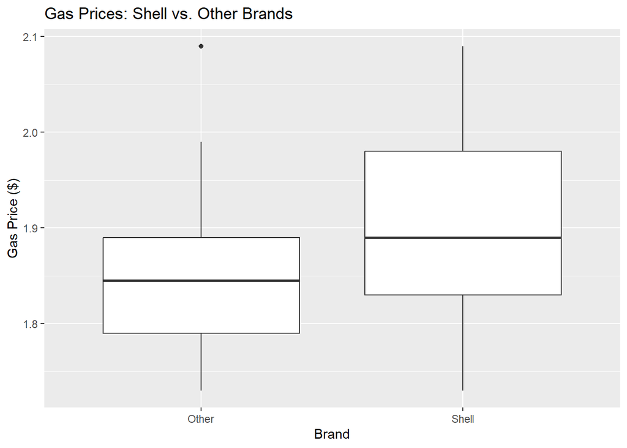

- Mean gas price for non-Shell stations (Other) = $1.85. Mean gas price for Shell stations = $1.884. Difference in means = $1.884 - $1.856 = $0.028 (2.8 cents). p-value = 0.1603, which is not statistically significant (p > 0.05).95% Confidence Interval for the price difference = (-$0.066, $0.011). Since this confidence interval includes zero, it means there is no significant difference in gas prices between Shell and non-Shell brands. e evidence does not support the claim that Shell gas stations charge more than non-Shell brands. The observed difference in gas prices (2.8 cents higher at Shell) is not statistically significant (p = 0.1603, which is > 0.05). Furthermore, the confidence interval includes zero, meaning that any difference could be due to random chance.

# Problem 2

## Part A

[output not shown]

```
##     2.5%    97.5%
## 26241.45 31813.20
```

## Part B

```
##      2.5%     97.5%
## 0.4164071 0.4530980
```

With 95% confidence i can predict that between 41% and 45% of 2014 S-Class 550’s were painted Black

# Problem 3

## Part A

Between Living with ed and My name is Earl, does one show perform better with Happienes?

```
##
##  Welch Two Sample t-test
##
## data:  Q1_Happy by Show
## t = 1.1676, df = 162.57, p-value = 0.2447
## alternative hypothesis: true difference in means between group Living with Ed and group My Name is Earl is not equal to 0
## 95 percent confidence interval:
##  -0.1030341  0.4011371
## sample estimates:
##  mean in group Living with Ed mean in group My Name is Earl
##                      3.926829                      3.777778
```

## Part B: Annoyance Levels between The Biggest Loser” and “The Apprentice: Los Angeles.”

```
##
##  Welch Two Sample t-test
##
## data:  Q1_Annoyed by Show
## t = 2.1032, df = 300.66, p-value = 0.03628
## alternative hypothesis: true difference in means between group The Apprentice: Los Angeles and group The Biggest Loser is not equal to 0
## 95 percent confidence interval:
##  0.01743792 0.52455614
## sample estimates:
## mean in group The Apprentice: Los Angeles
##                                  2.307229
##           mean in group The Biggest Loser
##                                  2.036232
```

The t-test results for Q1_Annoyed indicate a statistically significant difference in mean annoyance scores between *The Apprentice: Los Angeles* and *The Biggest Loser*. The mean annoyance score for *The Apprentice: Los Angeles* (2.31) is higher than that for *The Biggest Loser* (2.04), indicating that viewers found *The Apprentice: Los Angeles* significantly more annoying. Since the p-value is less than 0.05, we reject the null hypothesis and conclude that *The Apprentice: Los Angeles* tends to elicit higher annoyance ratings compared to *The Biggest Loser*.

## Part C: Do viewers Find Dancing with the stars Confusing?

```
## Proportion of viewers rating Q2_Confusing ≥ 4: 0.0773
```

```
## 95% Confidence Interval: ( 0.0384 , 0.1163 )
```

The analysis estimates that 7.73% of viewers rated *Dancing with the Stars* as confusing The 95% confidence interval for this proportion is (3.84%, 11.63%), meaning we are 95% confident that the true proportion of all American TV watchers who would give a confusion rating of 4 or higher falls within this range.

# Problem 4

```r
ebay <- read.csv("ebay.csv")

# Create a new column for revenue ratio
ebay <- ebay %>%
  mutate(revenue_ratio = rev_after / rev_before)

# Split data into treatment and control groups
treatment_group <- ebay %>% filter(adwords_pause == 1) %>% pull(revenue_ratio)
control_group <- ebay %>% filter(adwords_pause == 0) %>% pull(revenue_ratio)

# Compute observed difference in means
obs_diff <- mean(treatment_group) - mean(control_group)

# Bootstrap simulation (10,000 resamples)
set.seed(123)  # Set seed for reproducibility
n_simulations <- 10000
bootstrap_diffs <- replicate(n_simulations, {
  sample_treatment <- sample(treatment_group, size = length(treatment_group), replace = TRUE)
  sample_control <- sample(control_group, size = length(control_group), replace = TRUE)
  mean(sample_treatment) - mean(sample_control)
})

# Compute 95% confidence interval
CI <- quantile(bootstrap_diffs, probs = c(0.025, 0.975))

# Print results
cat("Observed Difference in Revenue Ratio:", obs_diff, "\n")
```

```
## Observed Difference in Revenue Ratio: -0.05228145
```

```r
cat("95% Confidence Interval: (", CI[1], ",", CI[2], ")\n")
```

```
## 95% Confidence Interval: ( -0.09137524 , -0.0129432 )
```

The observed difference in revenue ratio between the treatment group (AdWords paused) and the control group (AdWords active) is -0.0523. This means that, on average, the revenue ratio in the treatment group was 5.23 percentage points lower than in the control group. The results indicate that pausing paid search advertising on Google resulted in a significantly lower revenue ratio, suggesting that the ads were generating additional revenue for eBay. If paid search advertising had no effect, we would expect the revenue ratios to be similar between the treatment and control groups, but this is not the case. Instead, the confidence interval suggests that pausing ads led to a decline in revenue between 1.3% and 9.1%. Therefore, based on this analysis, paid search advertising on Google does contribute to extra revenue for eBay, and stopping it leads to a measurable decline in revenue performance.